# Interactive visualization of Civil War battle sites

SHA 2017 GIS workshop unit 4

# Maps on the internet

### [The DFW Election Dot Map](http://personal.tcu.edu/kylewalker/maps/dfw_election.html)

[interactive chart not shown]

### Web pages: client/server architecture

- **Web server** hosts and serves sites and data to be consumed by **web clients** (e.g. your browser)

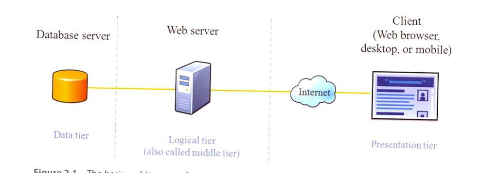

Source: Fu and Sun (2011)

# Tiled mapping

- To speed browsing, web maps often display map images as “tiles”
- Tiles are defined by their **zoom level** and **coordinates**
- Common coordinate system: **Web Mercator**

### How tiled mapping systems work

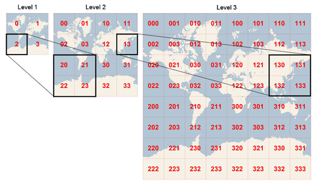

Source: Bing Maps

# CARTO

- Spatial database in the cloud
- ‘Freemium’ service; free to get started, more storage costs more money
- Powerful interface for running queries, visualizing your data; dashboard capabilities
- Link: http://www.carto.com

# Loading data into CARTO

# What makes a good web map?

- Brian Timoney: maps should be **fast**, **intuitive**, **informative**, and **fast**!
- This can be accomplished through **generalization**, **scalability**, and **minimalism**

# Generalization

- Important to consider purpose of your map when selecting resolution of your data

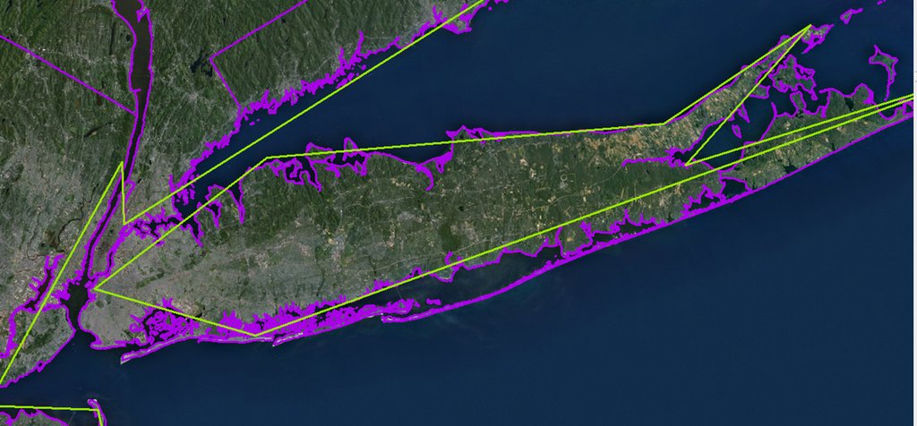

# Generalization

- At small scales, lots of detail can be unnecessary and computationally burdensome
- Large feature services can be very slow in web maps
- When building applications, ask yourself: how much detail do I need?
- In ArcGIS: look for the “Generalization” toolset in the “Cartography” toolbox

# Scalability

Example: [NPR Census Map](http://www.npr.org/censusmap)

### Minimalism (when appropriate)

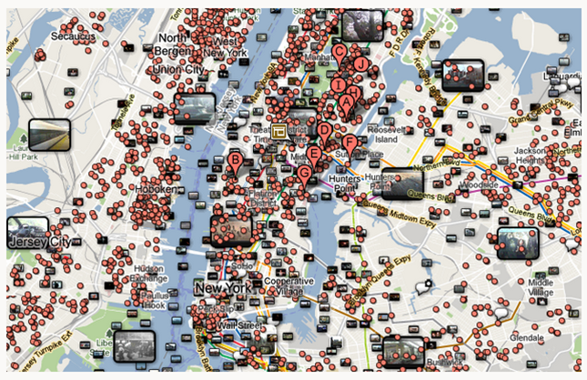

### Minimalist solution

[interactive chart not shown]